# Tidy Data

This notebook is student work of Tidy Data chapter as explained in the “Data Science: Wrangling” course.

Load gapminder module

```r
library(gapminder)
library(dplyr)
data(gapminder)
```

Read gapminder data and filter it

```r
head(gapminder)
```

| country | continent | year | lifeExp | pop | gdpPercap |
| --- | --- | --- | --- | --- | --- |
| Afghanistan | Asia | 1952 | 28.801 | 8425333 | 779.4453 |
| Afghanistan | Asia | 1957 | 30.332 | 9240934 | 820.8530 |
| Afghanistan | Asia | 1962 | 31.997 | 10267083 | 853.1007 |
| Afghanistan | Asia | 1967 | 34.020 | 11537966 | 836.1971 |
| Afghanistan | Asia | 1972 | 36.088 | 13079460 | 739.9811 |
| Afghanistan | Asia | 1977 | 38.438 | 14880372 | 786.1134 |

```r
tidy_data <- gapminder %>% filter(country %in% c("South Korea", "Germany", "India", "Singapore") ) %>% select(country, year, lifeExp)
```

Plot the data

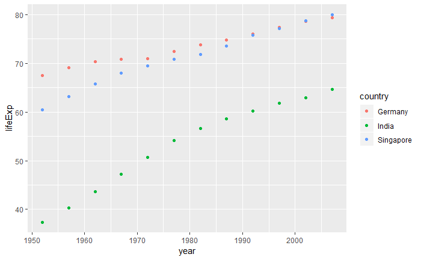

```r
library(ggplot2)
tidy_data %>% ggplot(aes(year, lifeExp, col = country)) + geom_point()
```

### Gather - Transpose wide data into column formmat

Lets get the wide formatted data from dslabs

```r
library(readr)
path <- system.file("extdata", package = "dslabs")
filename <- file.path(path, "fertility-two-countries-example.csv")
wide_data <- read_csv(filename)
head(wide_data)
```

| country | 1960 | 1961 | 1962 | 1963 | 1964 | 1965 | 1966 | 1967 | 1968 | 1969 | 1970 | 1971 | 1972 | 1973 | 1974 | 1975 | 1976 | 1977 | 1978 | 1979 | 1980 | 1981 | 1982 | 1983 | 1984 | 1985 | 1986 | 1987 | 1988 | … |
| --- | --- | --- | --- | --- | --- | --- | --- | --- | --- | --- | --- | --- | --- | --- | --- | --- | --- | --- | --- | --- | --- | --- | --- | --- | --- | --- | --- | --- | --- | --- |
| Germany | 2.41 | 2.44 | 2.47 | 2.49 | 2.49 | 2.48 | 2.44 | 2.37 | 2.28 | 2.17 | 2.04 | 1.92 | 1.80 | 1.70 | 1.62 | 1.56 | 1.53 | 1.50 | 1.49 | 1.48 | 1.47 | 1.47 | 1.46 | 1.46 | 1.46 | 1.45 | 1.44 | 1.43 | 1.41 | … |
| South Korea | 6.16 | 5.99 | 5.79 | 5.57 | 5.36 | 5.16 | 4.99 | 4.85 | 4.73 | 4.62 | 4.53 | 4.41 | 4.27 | 4.09 | 3.87 | 3.62 | 3.36 | 3.11 | 2.88 | 2.69 | 2.52 | 2.38 | 2.24 | 2.11 | 1.98 | 1.86 | 1.75 | 1.67 | 1.63 | … |

Reshape the data

```r
library(tidyverse)
new_tidy_data <- wide_data %>% gather(year, fertility, '1960':'2015')
# Can also be rewritten as
new_tidy_data <- wide_data %>% gather(year, fertility, -country)
head(new_tidy_data)
```

| country | year | fertility |
| --- | --- | --- |
| Germany | 1960 | 2.41 |
| South Korea | 1960 | 6.16 |
| Germany | 1961 | 2.44 |
| South Korea | 1961 | 5.99 |
| Germany | 1962 | 2.47 |
| South Korea | 1962 | 5.79 |

Convert the type to integer

```r
new_tidy_data <- wide_data %>% gather(year, fertility, -country, convert = TRUE)
head(new_tidy_data)
```

| country | year | fertility |
| --- | --- | --- |
| Germany | 1960 | 2.41 |
| South Korea | 1960 | 6.16 |
| Germany | 1961 | 2.44 |
| South Korea | 1961 | 5.99 |
| Germany | 1962 | 2.47 |
| South Korea | 1962 | 5.79 |

### Spread - Transpose tidy data into wide data

New spread the fertility data by country

```r
new_wide_data <- new_tidy_data %>% spread (country, fertility)
head(new_wide_data)
```

| year | Germany | South Korea |
| --- | --- | --- |
| 1960 | 2.41 | 6.16 |
| 1961 | 2.44 | 5.99 |
| 1962 | 2.47 | 5.79 |
| 1963 | 2.49 | 5.57 |
| 1964 | 2.49 | 5.36 |
| 1965 | 2.48 | 5.16 |

### Separate and unite the data

Read the data

```r
path <- system.file("extdata", package = "dslabs")
filename <- file.path(path, "life-expectancy-and-fertility-two-countries-example.csv")
raw_data <- read_csv(filename)
head(raw_data)
```

| country | 1960_fertility | 1960_life_expectancy | 1961_fertility | 1961_life_expectancy | 1962_fertility | 1962_life_expectancy | 1963_fertility | 1963_life_expectancy | 1964_fertility | 1964_life_expectancy | 1965_fertility | 1965_life_expectancy | 1966_fertility | 1966_life_expectancy | 1967_fertility | 1967_life_expectancy | 1968_fertility | 1968_life_expectancy | 1969_fertility | 1969_life_expectancy | 1970_fertility | 1970_life_expectancy | 1971_fertility | 1971_life_expectancy | 1972_fertility | 1972_life_expectancy | 1973_fertility | 1973_life_expectancy | 1974_fertility | … |
| --- | --- | --- | --- | --- | --- | --- | --- | --- | --- | --- | --- | --- | --- | --- | --- | --- | --- | --- | --- | --- | --- | --- | --- | --- | --- | --- | --- | --- | --- | --- |
| Germany | 2.41 | 69.26 | 2.44 | 69.85 | 2.47 | 70.01 | 2.49 | 70.10 | 2.49 | 70.66 | 2.48 | 70.65 | 2.44 | 70.77 | 2.37 | 70.99 | 2.28 | 70.64 | 2.17 | 70.48 | 2.04 | 70.72 | 1.92 | 70.94 | 1.80 | 71.16 | 1.70 | 71.41 | 1.62 | … |
| South Korea | 6.16 | 53.02 | 5.99 | 53.75 | 5.79 | 54.51 | 5.57 | 55.27 | 5.36 | 56.04 | 5.16 | 56.84 | 4.99 | 57.67 | 4.85 | 58.54 | 4.73 | 59.44 | 4.62 | 60.35 | 4.53 | 61.22 | 4.41 | 62.02 | 4.27 | 62.73 | 4.09 | 63.34 | 3.87 | … |

The problem is there are two variables life_expectancy and fertility appended to year.

So we will run: 1) Create a column VAR with values ( 1960_fertility, 1960_life_expectancy …. ) 2) Split the column into 2 columns, one having year and other the variable name ( life expectancy or fertility) 3) Use the spread function to create 2 columns life_expectancy & fertility

Step 1:

```r
s1_data <- raw_data %>% gather(var, val, -country)
head(s1_data)
```

| country | var | val |
| --- | --- | --- |
| Germany | 1960_fertility | 2.41 |
| South Korea | 1960_fertility | 6.16 |
| Germany | 1960_life_expectancy | 69.26 |
| South Korea | 1960_life_expectancy | 53.02 |
| Germany | 1961_fertility | 2.44 |
| South Korea | 1961_fertility | 5.99 |

Step 2:

```r
s2_data <- s1_data %>% separate(var, c("year", "variable_name"), sep = "_", extra = "merge" )
head(s2_data)
```

| country | year | variable_name | val |
| --- | --- | --- | --- |
| Germany | 1960 | fertility | 2.41 |
| South Korea | 1960 | fertility | 6.16 |
| Germany | 1960 | life_expectancy | 69.26 |
| South Korea | 1960 | life_expectancy | 53.02 |
| Germany | 1961 | fertility | 2.44 |
| South Korea | 1961 | fertility | 5.99 |

Step3:

```r
s3_data <- s2_data %>% spread( variable_name, val )
head(s3_data)
```

| country | year | fertility | life_expectancy |
| --- | --- | --- | --- |
| Germany | 1960 | 2.41 | 69.26 |
| Germany | 1961 | 2.44 | 69.85 |
| Germany | 1962 | 2.47 | 70.01 |
| Germany | 1963 | 2.49 | 70.10 |
| Germany | 1964 | 2.49 | 70.66 |
| Germany | 1965 | 2.48 | 70.65 |

### Combining Tables

Review the datasets used for exercise

```r
library(dslabs)
head(murders)
```

|  | state | abb | region | population | total |
| --- | --- | --- | --- | --- | --- |
| 1 | Alabama | AL | South | 4779736 | 135 |
| 2 | Alaska | AK | West | 710231 | 19 |
| 3 | Arizona | AZ | West | 6392017 | 232 |
| 4 | Arkansas | AR | South | 2915918 | 93 |
| 5 | California | CA | West | 37253956 | 1257 |
| 6 | Colorado | CO | West | 5029196 | 65 |

```r
head(results_us_election_2016)
```

|  | state | electoral_votes | clinton | trump | others |
| --- | --- | --- | --- | --- | --- |
| 1 | Alabama | 9 | 34.4 | 62.1 | 3.6 |
| 2 | Alaska | 3 | 36.6 | 51.3 | 12.2 |
| 3 | Arizona | 11 | 45.1 | 48.7 | 6.2 |
| 4 | Arkansas | 6 | 33.7 | 60.6 | 5.8 |
| 5 | California | 55 | 61.7 | 31.6 | 6.7 |
| 6 | Colorado | 9 | 48.2 | 43.3 | 8.6 |

Join murders and results_us_election_2016 datasets

```r
joined_ds <- left_join(murders, results_us_election_2016, by = "state") %>% select(state, abb, region, population, electoral_votes)
head(joined_ds)
```

|  | state | abb | region | population | electoral_votes |
| --- | --- | --- | --- | --- | --- |
| 1 | Alabama | AL | South | 4779736 | 9 |
| 2 | Alaska | AK | West | 710231 | 3 |
| 3 | Arizona | AZ | West | 6392017 | 11 |
| 4 | Arkansas | AR | South | 2915918 | 6 |
| 5 | California | CA | West | 37253956 | 55 |
| 6 | Colorado | CO | West | 5029196 | 9 |

Take subset of data from these 2 tables to run various joins

```r
tab1 <- slice(murders, 1:6) %>% select(state, population)
tab2 <- slice(results_us_election_2016, c(1:3, 5, 7:8) ) %>% select(state, electoral_votes)
```

**Inner join** - joins two datasets by the key and only returns matching datasets

```r
inner_join(tab1, tab2, by = "state")
```

| state | population | electoral_votes |
| --- | --- | --- |
| Alabama | 4779736 | 9 |
| Alaska | 710231 | 3 |
| Arizona | 6392017 | 11 |
| California | 37253956 | 55 |

Another suported syntax

```r
tab1 %>% inner_join(tab2, by = "state")
```

| state | population | electoral_votes |
| --- | --- | --- |
| Alabama | 4779736 | 9 |
| Alaska | 710231 | 3 |
| Arizona | 6392017 | 11 |
| California | 37253956 | 55 |

**Left join** - results in taking everything from left dataset ( tab1 ) and matching data from tab2

```r
left_join(tab1, tab2, by = "state")
```

| state | population | electoral_votes |
| --- | --- | --- |
| Alabama | 4779736 | 9 |
| Alaska | 710231 | 3 |
| Arizona | 6392017 | 11 |
| Arkansas | 2915918 | NA |
| California | 37253956 | 55 |
| Colorado | 5029196 | NA |

Another suported syntax

```r
tab1 %>% left_join(tab2, by = "state")
```

| state | population | electoral_votes |
| --- | --- | --- |
| Alabama | 4779736 | 9 |
| Alaska | 710231 | 3 |
| Arizona | 6392017 | 11 |
| Arkansas | 2915918 | NA |
| California | 37253956 | 55 |
| Colorado | 5029196 | NA |

**Right join** - results in taking in everything from right dataset ( tab2 ) and matching data from tab1

```r
right_join(tab1, tab2, by = "state")
```

| state | population | electoral_votes |
| --- | --- | --- |
| Alabama | 4779736 | 9 |
| Alaska | 710231 | 3 |
| Arizona | 6392017 | 11 |
| California | 37253956 | 55 |
| Connecticut | NA | 7 |
| Delaware | NA | 3 |

Another suported syntax

```r
tab1 %>% right_join(tab2, by = "state")
```

| state | population | electoral_votes |
| --- | --- | --- |
| Alabama | 4779736 | 9 |
| Alaska | 710231 | 3 |
| Arizona | 6392017 | 11 |
| California | 37253956 | 55 |
| Connecticut | NA | 7 |
| Delaware | NA | 3 |

**Full join** - results in taking in everything from left dataset ( tab1 ) right dataset ( tab2 )

```r
full_join(tab1, tab2, by = "state")
```

| state | population | electoral_votes |
| --- | --- | --- |
| Alabama | 4779736 | 9 |
| Alaska | 710231 | 3 |
| Arizona | 6392017 | 11 |
| Arkansas | 2915918 | NA |
| California | 37253956 | 55 |
| Colorado | 5029196 | NA |
| Connecticut | NA | 7 |
| Delaware | NA | 3 |

Another suported syntax

```r
tab1 %>% full_join(tab2, by = "state")
```

| state | population | electoral_votes |
| --- | --- | --- |
| Alabama | 4779736 | 9 |
| Alaska | 710231 | 3 |
| Arizona | 6392017 | 11 |
| Arkansas | 2915918 | NA |
| California | 37253956 | 55 |
| Colorado | 5029196 | NA |
| Connecticut | NA | 7 |
| Delaware | NA | 3 |

**Semi join** - keeps the records in left dataset ( tab1 ) if there are matching records in right dataset ( tab2 ) Semi Join will not bring any columns from right dataset ( tab 2 )

```r
semi_join(tab1, tab2, by = "state")
```

| state | population |
| --- | --- |
| Alabama | 4779736 |
| Alaska | 710231 |
| Arizona | 6392017 |
| California | 37253956 |

Another suported syntax

```r
tab1 %>% semi_join(tab2, by = "state")
```

| state | population |
| --- | --- |
| Alabama | 4779736 |
| Alaska | 710231 |
| Arizona | 6392017 |
| California | 37253956 |

**Anti join** - is opposite of Semi join - it removes records in left dataset ( tab1 ) if there are matching records in right dataset ( tab2 ). Like semi Join, Anti Join will not bring any columns from right dataset ( tab 2 )

```r
anti_join(tab1, tab2, by = "state")
```

| state | population |
| --- | --- |
| Arkansas | 2915918 |
| Colorado | 5029196 |

Another suported syntax

```r
tab1 %>% anti_join(tab2, by = "state")
```

| state | population |
| --- | --- |
| Arkansas | 2915918 |
| Colorado | 5029196 |

### Web Scraping

rvest package helps scape the web

```r
library(rvest)
```

Read the data from Wikipedia

```r
url <- "https://en.wikipedia.org/wiki/Murder_in_the_United_States_by_state"
h <- read_html(url)
h
```

```
{xml_document}
<html class="client-nojs" lang="en" dir="ltr">
[1] <head>\n<meta http-equiv="Content-Type" content="text/html; charset=UTF-8">\n<meta charset="UTF-8">\n<title>Gun violence in the United Stat ...
[2] <body class="mediawiki ltr sitedir-ltr mw-hide-empty-elt ns-0 ns-subject page-Gun_violence_in_the_United_States_by_state rootpage-Gun_viole ...
```

Extract the tables from HTML code

```r
tabs <- html_nodes(h, "table")
tabs
```

```
{xml_nodeset (3)}
[1] <table class="wikitable">\n<caption>Legend\n</caption>\n<tbody><tr>\n<th style="background: White">Lowest\n</th>\n<th style="background: #c ...
[2] <table class="wikitable sortable"><tbody>\n<tr>\n<th data-sort-type="text">State\n</th>\n<th data-sort-type="number">Population<br><small>( ...
[3] <table class="nowraplinks hlist collapsible collapsed navbox-inner" style="border-spacing:0;background:transparent;color:inherit"><tbody>\n ...
```

Table the 2nd table and get the html table out of it

[output not shown]

Lets look at the structure of the table mdrs

```r
str(mdrs)
```

```
'data.frame':   51 obs. of  9 variables:
 $ State                                                       : chr  "Alabama" "Alaska" "Arizona" "Arkansas" ...
 $ Population(total inhabitants) (2015) [2]                    : chr  "4,853,875" "737,709" "6,817,565" "2,977,853" ...
 $ Murders andNonnegligentManslaughter(total deaths) (2015) [1]: chr  "348" "59" "309" "181" ...
 $ Murders(total deaths) (2015) [3]                            : chr  "3[a]" "57" "278" "164" ...
 $ Gun Murders(total deaths) (2015) [3]                        : chr  "3[a]" "39" "171" "110" ...
 $ GunOwnership(%) (2013) [4]                                  : num  48.9 61.7 32.3 57.9 20.1 34.3 16.6 5.2 25.9 32.5 ...
 $ Murder andNonnegligentManslaughterRate(per 100,000) (2015)  : num  7.2 8 4.5 6.1 4.8 3.2 3.3 6.7 24.2 5.1 ...
 $ Murder Rate(per 100,000) (2015)                             : chr  "0.1[a]" "7.7" "4.1" "5.5" ...
 $ GunMurder Rate(per 100,000) (2015)                          : chr  "0.1[a]" "5.3" "2.5" "3.7" ...
```

Lets change the column names to proper names

```r
names(mdrs) = c("state", "population", "total_deaths", "murders", "gun_murders", "gun_ownership", "total_rate", "murder_rate", "gun_murder_rate")
str(mdrs)
```

[output not shown]